# Modeling User App Rating

Devin Romines and Joseph Audras  
May 13, 2019

### I. Introduction

Google Play Store Data Set

- Contains data on over 10,000 apps
- Looks at user rating, number of installations, and more
- Scraped by Lavanya Gupta, a software enginere at HSBC Software Development
- Last updated 2 months ago

More information about the data set can be found at https://www.kaggle.com/lava18/google-play-store-apps.

Our goal with this data is to build two models that can accurately predict the user rating score.

### II. Data Dictionary

These are the apps we will be looking at.

- Rating (Numerical), the rating of the app on a scale from 0-5
- Category (Factor), the general type of app, such as Dating, Cooking, or Art and Design
- Reviews (Numerical), the number of reviews that the app received
- Installs (Numerical), the number of installations the app received
- Price (Numerical), the price of the app
- Content.Rating (Factor), the rating for the app, Everyone, Teen, etc.

### III. Data Cleaning

Part 1: Preparing the Data

For data cleaning, we had to make sure that we converted all variables to the type that they should be, like Installs and Price to numeric, and removing any variables we wouldn't need.

```r
GooglePlayStore$Price <- gsub("[[:punct:]]", "", GooglePlayStore$Price)
GooglePlayStore$Price <- as.numeric(GooglePlayStore$Price)
GooglePlayStore$Price <- GooglePlayStore$Price/100
```

### III. Data Cleaning

Part 2: Splitting the Data

Because we intend on making a predictive model, we split the data into a testing and training data set.

```r
set.seed(42)
GooglePlayStoreTemp <- GooglePlayStore %>% mutate(id=row_number())
Train <- GooglePlayStoreTemp %>% sample_frac(0.6)
Test <- GooglePlayStoreTemp %>% anti_join(Train,by="id")
Train$id <- NULL
Test$id <- NULL
write.csv(Test,"Test.csv",row.names = FALSE)
rm(Test,GooglePlayStoreTemp)
```

### IV. Exploratory Data Analysis

Part 1: Reviews vs. Rating

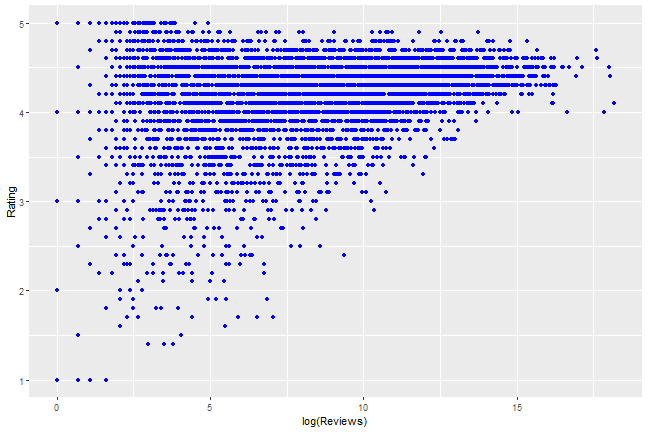

```r
ggplot(Train) + geom_point(aes(x=log(Reviews),y=Rating), color="blue")
```

### IV. Exploratory Data Analysis

Part 2: Installs vs. Rating

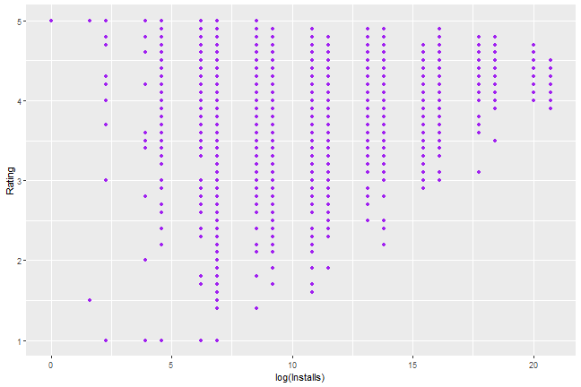

```r
ggplot(Train) + geom_point(aes(x=log(Installs),y=Rating), color="purple")
```

### IV. Exploratory Data Analysis

Part 3: Price vs. Rating

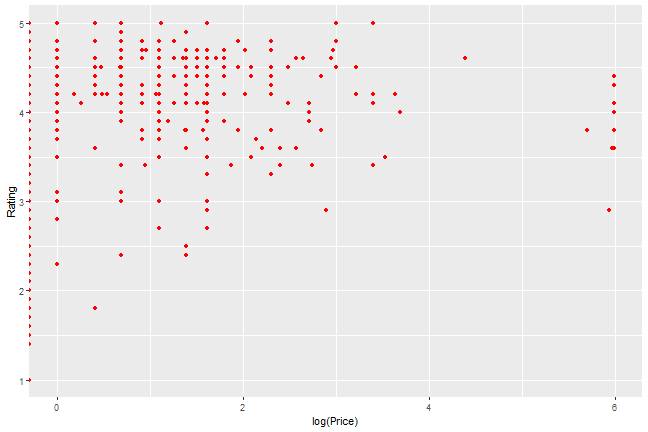

```r
ggplot(Train) + geom_point(aes(x=log(Price),y=Rating), color="red")
```

### IV. Exploratory Data Analysis

Part 4: Content Rating vs. Rating

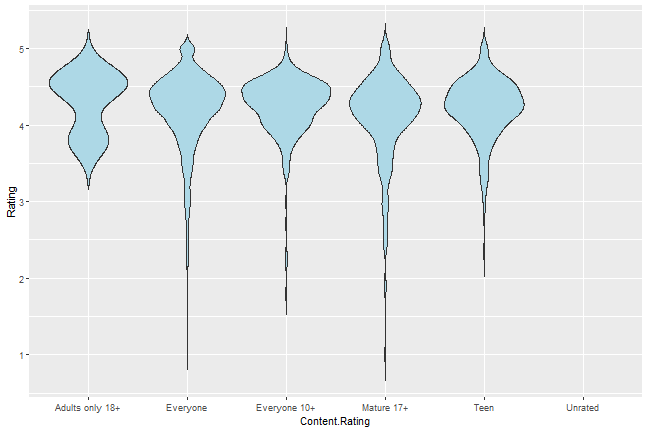

```r
ggplot(Train) + geom_violin(aes(x=Content.Rating,y=Rating), trim=FALSE, fill="light blue")
```

### IV. Exploratory Data Analysis

Part 5: Conclusions

Moving forward, we feel that the models we are aiming to create should include the Review, Installs, and Price variables, possibly Content Rating and Category as well.

### V. Broad Questions

What makes a good app?

- An app's “good"ness will be determined by the user rating score
- Creating a predictive model will show us if any app characteristics contribute to its "goodness”

Can we know in advance if an app will be good?

- Based on characteristics known before an app is released
- Will be useful for app developers in deciding which apps to support, develop, and market

### V. Narrow Questions

Can we create a model that accurately predicts an app's user rating based on these variables?

- Number of reviews and installations
- Price and Category

Can we create a model that accurately predicts and app's user rating based purely on variables that would be known before the app is released?

- Content Rating
- Price
- Category

### VI. Model Building

Part 1: Unconditional Random Forest Model

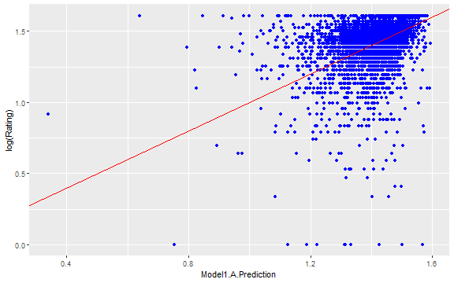

```r
library(randomForest)
set.seed(42)
Model1.A <- randomForest(I(log(Rating)) ~ Reviews + Installs + Price + Category, data = Train, mtry = 4)
Model1.A.Prediction <- predict(Model1.A)
ggplot(Train) + geom_point(aes(x=Model1.A.Prediction,y=log(Rating)),color = "blue") +
  geom_abline(intercept = 0, color = "red")
```

### VI. Model Building

Part 2: Conditional Random Forest Model

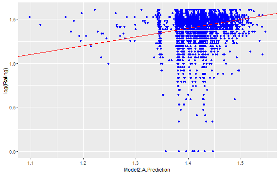

```r
set.seed(42)
Model2.A <- randomForest(I(log(Rating)) ~ Price + Category + Content.Rating, data = Train, mtry = 3)
Model2.A.Prediction <- predict(Model2.A)
ggplot(Train) + geom_point(aes(x=Model2.A.Prediction,y=log(Rating)),color = "blue") +
  geom_abline(intercept = 0, color = "red")
```

### VI. Model Testing

Part 1: Unconditional Model Test

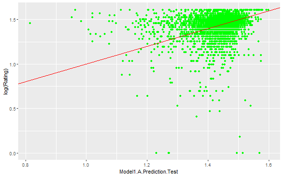

```r
Test <- read.csv("Test.csv")
levels(Test$Category) <- levels(Train$Category)
Model1.A.Prediction.Test <- predict(Model1.A,newdata=Test)
ggplot(Test) + geom_point(aes(x=Model1.A.Prediction.Test,y=log(Rating)),color = "green") +
  geom_abline(intercept = 0, color = "red")
```

### VI. Model Testing

Part 2: Conditional Model Test

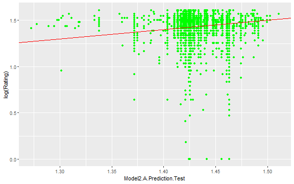

```r
levels(Test$Category) <- levels(Train$Category)
levels(Test$Content.Rating) <- levels(Train$Content.Rating)
Model2.A.Prediction.Test <- predict(Model2.A,newdata=Test)
ggplot(Test) + geom_point(aes(x=Model2.A.Prediction.Test,y=log(Rating)),color = "green") +
  geom_abline(intercept = 0, color = "red")
```

### VII. Results

Overall, we generated two models, an unconditional model and a conditional model to predict user rating scores.